> **Tip**: Welcome to the Investigate a Dataset project! You will find tips in quoted sections like this to help organize your approach to your investigation. Before submitting your project, it will be a good idea to go back through your report and remove these sections to make the presentation of your work as tidy as possible. First things first, you might want to double-click this Markdown cell and change the title so that it reflects your dataset and investigation.

# project investigate TMDb dataset.

- INTRODUCTION
- Data Wrangling
- Exploratory Data Analysis
- Conclusions

## Introduction

### this project will investegate imbd movies review dataset. i will try to find trends about movies with good reviews in comparsion with movies with bad review

```python
import pandas as pd
import numpy as np
import matplotlib.pyplot as plt

import warnings
warnings.filterwarnings("ignore")
```

# Data Wrangling

### General Properties

```python
df =pd.read_csv("C:\\Users\\Dell\\Downloads\\movies.csv")
df.head()
```

|  | id | imdb_id | popularity | budget | revenue | original_title | cast | homepage | director | tagline | ... | overview | runtime | genres | production_companies | release_date | vote_count | vote_average | release_year | budget_adj | revenue_adj |
| --- | --- | --- | --- | --- | --- | --- | --- | --- | --- | --- | --- | --- | --- | --- | --- | --- | --- | --- | --- | --- | --- |
| 0 | 135397 | tt0369610 | 32.985763 | 150000000 | 1513528810 | Jurassic World | Chris Pratt\|Bryce Dallas Howard\|Irrfan Khan\|Vi... | http://www.jurassicworld.com/ | Colin Trevorrow | The park is open. | ... | Twenty-two years after the events of Jurassic ... | 124 | Action\|Adventure\|Science Fiction\|Thriller | Universal Studios\|Amblin Entertainment\|Legenda... | 6/9/15 | 5562 | 6.5 | 2015 | 1.379999e+08 | 1.392446e+09 |
| 1 | 76341 | tt1392190 | 28.419936 | 150000000 | 378436354 | Mad Max: Fury Road | Tom Hardy\|Charlize Theron\|Hugh Keays-Byrne\|Nic... | http://www.madmaxmovie.com/ | George Miller | What a Lovely Day. | ... | An apocalyptic story set in the furthest reach... | 120 | Action\|Adventure\|Science Fiction\|Thriller | Village Roadshow Pictures\|Kennedy Miller Produ... | 5/13/15 | 6185 | 7.1 | 2015 | 1.379999e+08 | 3.481613e+08 |
| 2 | 262500 | tt2908446 | 13.112507 | 110000000 | 295238201 | Insurgent | Shailene Woodley\|Theo James\|Kate Winslet\|Ansel... | http://www.thedivergentseries.movie/#insurgent | Robert Schwentke | One Choice Can Destroy You | ... | Beatrice Prior must confront her inner demons ... | 119 | Adventure\|Science Fiction\|Thriller | Summit Entertainment\|Mandeville Films\|Red Wago... | 3/18/15 | 2480 | 6.3 | 2015 | 1.012000e+08 | 2.716190e+08 |
| 3 | 140607 | tt2488496 | 11.173104 | 200000000 | 2068178225 | Star Wars: The Force Awakens | Harrison Ford\|Mark Hamill\|Carrie Fisher\|Adam D... | http://www.starwars.com/films/star-wars-episod... | J.J. Abrams | Every generation has a story. | ... | Thirty years after defeating the Galactic Empi... | 136 | Action\|Adventure\|Science Fiction\|Fantasy | Lucasfilm\|Truenorth Productions\|Bad Robot | 12/15/15 | 5292 | 7.5 | 2015 | 1.839999e+08 | 1.902723e+09 |
| 4 | 168259 | tt2820852 | 9.335014 | 190000000 | 1506249360 | Furious 7 | Vin Diesel\|Paul Walker\|Jason Statham\|Michelle ... | http://www.furious7.com/ | James Wan | Vengeance Hits Home | ... | Deckard Shaw seeks revenge against Dominic Tor... | 137 | Action\|Crime\|Thriller | Universal Pictures\|Original Film\|Media Rights ... | 4/1/15 | 2947 | 7.3 | 2015 | 1.747999e+08 | 1.385749e+09 |

5 rows × 21 columns

```python
df.columns
```

```
Index(['id', 'imdb_id', 'popularity', 'budget', 'revenue', 'original_title',
       'cast', 'homepage', 'director', 'tagline', 'keywords', 'overview',
       'runtime', 'genres', 'production_companies', 'release_date',
       'vote_count', 'vote_average', 'release_year', 'budget_adj',
       'revenue_adj'],
      dtype='object')
```

```python
df.drop(['id','imdb_id','cast'],inplace=True,axis=1)
```

```python
df.dtypes
```

```
popularity              float64
budget                    int64
revenue                   int64
original_title           object
homepage                 object
director                 object
tagline                  object
keywords                 object
overview                 object
runtime                   int64
genres                   object
production_companies     object
release_date             object
vote_count                int64
vote_average            float64
release_year              int64
budget_adj              float64
revenue_adj             float64
dtype: object
```

```python
df.shape
```

```
(10866, 18)
```

```python
df.info()
```

```
<class 'pandas.core.frame.DataFrame'>
RangeIndex: 10866 entries, 0 to 10865
Data columns (total 18 columns):
 #   Column                Non-Null Count  Dtype
---  ------                --------------  -----
 0   popularity            10866 non-null  float64
 1   budget                10866 non-null  int64
 2   revenue               10866 non-null  int64
 3   original_title        10866 non-null  object
 4   homepage              2936 non-null   object
 5   director              10822 non-null  object
 6   tagline               8042 non-null   object
 7   keywords              9373 non-null   object
 8   overview              10862 non-null  object
 9   runtime               10866 non-null  int64
 10  genres                10843 non-null  object
 11  production_companies  9836 non-null   object
 12  release_date          10866 non-null  object
 13  vote_count            10866 non-null  int64
 14  vote_average          10866 non-null  float64
 15  release_year          10866 non-null  int64
 16  budget_adj            10866 non-null  float64
 17  revenue_adj           10866 non-null  float64
dtypes: float64(4), int64(5), object(9)
memory usage: 1.5+ MB
```

```python
df.columns
```

```
Index(['popularity', 'budget', 'revenue', 'original_title', 'homepage',
       'director', 'tagline', 'keywords', 'overview', 'runtime', 'genres',
       'production_companies', 'release_date', 'vote_count', 'vote_average',
       'release_year', 'budget_adj', 'revenue_adj'],
      dtype='object')
```

```python
df.isnull().sum()
```

```
popularity                 0
budget                     0
revenue                    0
original_title             0
homepage                7930
director                  44
tagline                 2824
keywords                1493
overview                   4
runtime                    0
genres                    23
production_companies    1030
release_date               0
vote_count                 0
vote_average               0
release_year               0
budget_adj                 0
revenue_adj                0
dtype: int64
```

```python
df.describe()
```

|  | popularity | budget | revenue | runtime | vote_count | vote_average | release_year | budget_adj | revenue_adj |
| --- | --- | --- | --- | --- | --- | --- | --- | --- | --- |
| count | 10866.000000 | 1.086600e+04 | 1.086600e+04 | 10866.000000 | 10866.000000 | 10866.000000 | 10866.000000 | 1.086600e+04 | 1.086600e+04 |
| mean | 0.646441 | 1.462570e+07 | 3.982332e+07 | 102.070863 | 217.389748 | 5.974922 | 2001.322658 | 1.755104e+07 | 5.136436e+07 |
| std | 1.000185 | 3.091321e+07 | 1.170035e+08 | 31.381405 | 575.619058 | 0.935142 | 12.812941 | 3.430616e+07 | 1.446325e+08 |
| min | 0.000065 | 0.000000e+00 | 0.000000e+00 | 0.000000 | 10.000000 | 1.500000 | 1960.000000 | 0.000000e+00 | 0.000000e+00 |
| 25% | 0.207583 | 0.000000e+00 | 0.000000e+00 | 90.000000 | 17.000000 | 5.400000 | 1995.000000 | 0.000000e+00 | 0.000000e+00 |
| 50% | 0.383856 | 0.000000e+00 | 0.000000e+00 | 99.000000 | 38.000000 | 6.000000 | 2006.000000 | 0.000000e+00 | 0.000000e+00 |
| 75% | 0.713817 | 1.500000e+07 | 2.400000e+07 | 111.000000 | 145.750000 | 6.600000 | 2011.000000 | 2.085325e+07 | 3.369710e+07 |
| max | 32.985763 | 4.250000e+08 | 2.781506e+09 | 900.000000 | 9767.000000 | 9.200000 | 2015.000000 | 4.250000e+08 | 2.827124e+09 |

### the previous table show that half of budget and revenue column is 0 which needs to be handled so i will consider it as null values and replace it with the mean but it won't be very accurate beacause the huge number of values equel to zero

### i will build replace_zero_mean function in order to replace zero values of the with tme mean as the name of the function inspires

```python
def replace_zero_mean(feature):
    feature_mean = df[feature].mean()
    df[feature]=df[feature].replace([0],feature_mean)
```

### applying the function on the target features

```python
replace_zero_mean('revenue')
replace_zero_mean('budget')
replace_zero_mean('budget_adj')
replace_zero_mean('revenue_adj')
```

# check that the changes has done

```python
df.describe()
```

|  | popularity | budget | revenue | runtime | vote_count | vote_average | release_year | budget_adj | revenue_adj |
| --- | --- | --- | --- | --- | --- | --- | --- | --- | --- |
| count | 10866.000000 | 1.086600e+04 | 1.086600e+04 | 10866.000000 | 10866.000000 | 10866.000000 | 10866.000000 | 1.086600e+04 | 1.086600e+04 |
| mean | 0.646441 | 2.229255e+07 | 6.187164e+07 | 102.070863 | 217.389748 | 5.974922 | 2001.322658 | 2.675136e+07 | 7.980243e+07 |
| std | 1.000185 | 2.801245e+07 | 1.110204e+08 | 31.381405 | 575.619058 | 0.935142 | 12.812941 | 3.050850e+07 | 1.365610e+08 |
| min | 0.000065 | 1.000000e+00 | 2.000000e+00 | 0.000000 | 10.000000 | 1.500000 | 1960.000000 | 9.210911e-01 | 2.370705e+00 |
| 25% | 0.207583 | 1.462570e+07 | 3.982332e+07 | 90.000000 | 17.000000 | 5.400000 | 1995.000000 | 1.755104e+07 | 5.136436e+07 |
| 50% | 0.383856 | 1.462570e+07 | 3.982332e+07 | 99.000000 | 38.000000 | 6.000000 | 2006.000000 | 1.755104e+07 | 5.136436e+07 |
| 75% | 0.713817 | 1.500000e+07 | 3.982332e+07 | 111.000000 | 145.750000 | 6.600000 | 2011.000000 | 2.085325e+07 | 5.136436e+07 |
| max | 32.985763 | 4.250000e+08 | 2.781506e+09 | 900.000000 | 9767.000000 | 9.200000 | 2015.000000 | 4.250000e+08 | 2.827124e+09 |

# DATA CLEANING

## drop homepage features beacuse of too many missing

```python
df.drop('homepage',axis=1,inplace=True)
```

```python
df.tagline
```

```
0                                        The park is open.
1                                       What a Lovely Day.
2                               One Choice Can Destroy You
3                            Every generation has a story.
4                                      Vengeance Hits Home
                               ...
10861                                                  NaN
10862    Cinerama sweeps YOU into a drama of speed and ...
10863                                                  NaN
10864                            WOODY ALLEN STRIKES BACK!
10865         It's Shocking! It's Beyond Your Imagination!
Name: tagline, Length: 10866, dtype: object
```

```python
df.drop('tagline',axis=1,inplace=True)
```

# i will drop all null values as i can not replace the with values

```python
df.dropna(inplace=True,axis =0 )
df.isnull().sum()
```

```
popularity              0
budget                  0
revenue                 0
original_title          0
director                0
keywords                0
overview                0
runtime                 0
genres                  0
production_companies    0
release_date            0
vote_count              0
vote_average            0
release_year            0
budget_adj              0
revenue_adj             0
dtype: int64
```

## Exploratory Data Analysis

# what was the most popular movie each year ?

```python
years =set(df.release_year.values)
top_movies=[]
print("Top movie each Year\n\n")
for year in years :
    top_movies.append(df[df.release_year== year].sort_values(by='popularity',ignore_index=True,ascending=False)['original_title'][0])
    print(year, df[df.release_year== year].sort_values(by='popularity',ignore_index=True,ascending=False)['original_title'][0])
```

```
Top movie each Year


1960 Psycho
1961 One Hundred and One Dalmatians
1962 Dr. No
1963 From Russia With Love
1964 Goldfinger
1965 Thunderball
1966 How the Grinch Stole Christmas!
1967 The Jungle Book
1968 2001: A Space Odyssey
1969 On Her Majesty's Secret Service
1970 The Aristocats
1971 A Clockwork Orange
```

[output cut: 44 more lines]

## explore the vote average feature

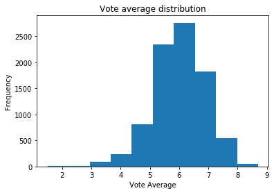

```python
plt.hist('vote_average',data=df);
plt.xlabel("Vote Average")
plt.ylabel("Frequency")
plt.title("Vote average distribution")
plt.show()
```

### distrubution is slightly skewd to the left

# explore runtime distribution

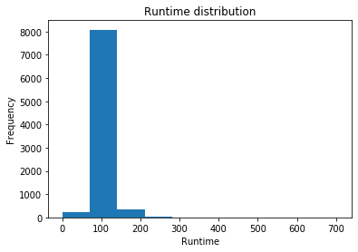

```python
plt.hist('runtime',data=df);
plt.xlabel("Runtime")
plt.ylabel("Frequency")
plt.title("Runtime distribution")
plt.show()
```

### the previous plot show that majorty of the movies are about 100 miniutes

# explore the relation between runtime and average vote

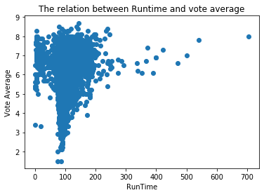

```python
plt.scatter(x='runtime',y='vote_average',data=df)
plt.title("The relation between Runtime and vote average")
plt.xlabel("RunTime")
plt.ylabel("Vote Average")
plt.show()
```

### there is no relation between runtime and vote average

```python
col=[]
for title in df['original_title'] :
    if(title in top_movies):
        col.append('r')
    else:
        col.append('b')
```

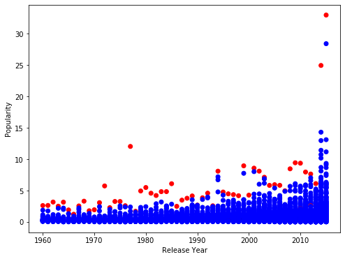

```python
plt.figure(figsize=(8,6))
plt.scatter('release_year','popularity',data=df ,c=col)
plt.xlabel("Release Year")
plt.ylabel("Popularity")
plt.show()
```

### the prevoious plot visualize shows that the popularity of the movies increase each year and it also highlights the top movie for each year

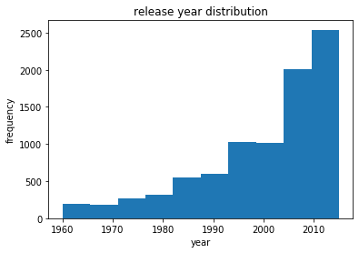

```python
plt.hist(x='release_year',data=df)
plt.title("release year distribution")
plt.xlabel("year")
plt.ylabel("frequency")
plt.show()
```

## the previos distribution show that most of movies included in the dataset are produced after 2000

```python
print(df[df.release_year<2000][['vote_average']].mean())
print(df[df.release_year>2000][['vote_average']].mean())
```

```
vote_average    6.115595
dtype: float64
vote_average    5.939969
dtype: float64
```

# vote average of movies produced before 2000 is higher than movies produced after

```python
print(df[df.release_year<2000][['vote_count']].mean())
print(df[df.release_year>2000][['vote_count']].mean())
```

```
vote_count    156.409255
dtype: float64
vote_count    333.238077
dtype: float64
```

#### the number of voters increased after 2000

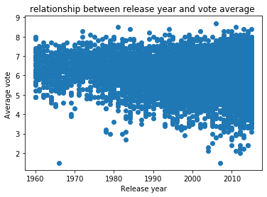

```python
plt.scatter(x='release_year',y='vote_average',data=df)
plt.title("relationship between release year and vote average ")
plt.xlabel("Release year")
plt.ylabel("Average vote ")
```

## explore what is common between Top movies

### 1- is it production company ?

```python
companies = []
for i in top_movies :
    c =df[df.original_title == i]['production_companies'].iloc[0]
    companies.append(c)
```

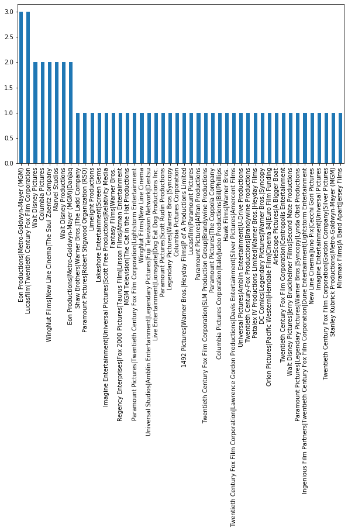

```python
companies_ =pd.Series(companies)
companies_.value_counts().plot(kind="bar",figsize=(10,5))
```

### the previous bar plot shows that the most popular movies dose not depend a lot on the production companies, i will check if there a single company is in common

```python
d =[company.split('|') for company in companies]
```

```python
d =pd.Series(list(zip(*d))[0])
```

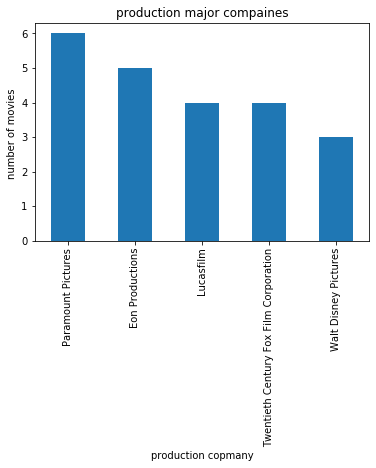

```python
d.value_counts()[0:5].plot(kind='bar')
plt.title("production major compaines")
plt.xlabel("production copmany")
plt.ylabel("number of movies ")
plt.show()
```

#### the previos plot shows that there are 2 major production comapnies "paramount picture and Eon producions".

# Q does budget relatedt movie sucess ??

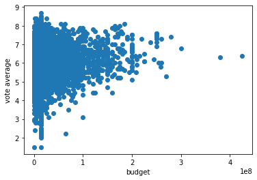

```python
plt.scatter("budget","vote_average",data=df)
plt.xlabel("budget")
plt.ylabel("vote average")
plt.show()
```

[figure not shown]

```python
plt.scatter("budget","popularity",data=df)
plt.xlabel("budget")
plt.ylabel("vote average")
plt.show()
```

### the previous scatter plots shows that high budget only will not make a movie successful movie.

# Explorle if there any movie dose not success

```python
df[df.budget >df.revenue_adj][["original_title","vote_average"]]
```

|  | original_title | vote_average |
| --- | --- | --- |
| 11 | Jupiter Ascending | 5.2 |
| 57 | Mortdecai | 5.3 |
| 59 | Blackhat | 5.0 |
| 66 | In the Heart of the Sea | 6.4 |
| 72 | Beyond the Reach | 5.5 |
| ... | ... | ... |
| 10607 | Soylent Green | 6.6 |
| 10661 | Zabriskie Point | 6.5 |
| 10683 | The Private Life of Sherlock Holmes | 6.7 |
| 10728 | The Wild Bunch | 7.2 |
| 10817 | The Last Waltz | 8.0 |

1355 rows × 2 columns

# comparsion between average rate of successfull and falied movies

```python
print(df[df.budget >= df.revenue_adj]["vote_average"].mean())
print(df[df.budget <df.revenue_adj]["vote_average"].mean())
```

```
5.903542435424354
6.02481940847756
```

```python
print(df[df.budget >= df.revenue_adj]["popularity"].mean())
print(df[df.budget <df.revenue_adj]["popularity"].mean())
```

```
0.5891379564575654
0.768405798146382
```

# conclusions

### high budget only dose not imply movies success

### successful movies have an average rate bigger than unsuccessful

### successul movies are more popualar than un successful